# PUC-SP Computing

Module 04 – R Markdown

Adriana Picoral

6/14/2021

# 1 Big title

You enter your text normally, and because it is not R, you won’t get a parsing error. It will render as text. To do to italics *these words are in italics*. For bold, **these words are in bold**.

*italics*

**bold**

*This sentence is in italics **but I want some bold in there***

## 1.1 Second level title

I would enter my text here.

### 1.1.1 Third level title

Reasons to learn R markdown:

- Separate semantics and formatting – easier to change formatting
- Include R code into your prose – reproducible research

I can create the same list, but ordered:

1. You don’t have to keep track of numbers
2. Markdown generates the correct order for you
3. So you can add an item anywhere
4. When you change your data, all tables and plots update automatically – just hit knit

> “Don’t use Word, it breaks my heart” – Adriana Picoral

# 2 Emma book vs. script

## 2.1 Read data in

Use shortcut *cmd/crtl + option/alt + i* to create a R code chunk.

```r
annotated_tokens_emma <- read_tsv("processed-data/annotated-data.tsv")
```

```
## Rows: 204,795
## Columns: 13
## $ doc_id        <chr> "text1", "text1", "text1", "text1", "text1", "text1", "t…
## $ sentence_id   <dbl> 1, 1, 2, 2, 2, 2, 3, 3, 3, 1, 1, 1, 1, 1, 1, 1, 1, 1, 1,…
## $ token_id      <dbl> 1, 2, 1, 2, 3, 4, 1, 2, 3, 1, 2, 3, 4, 5, 6, 7, 8, 9, 1,…
## $ token         <chr> "Ho", "!", "Ho", ",", "there", "!", "Stop", "thief", "!"…
## $ lemma         <chr> "ho", "!", "Ho", ",", "there", "!", "stop", "thief", "!"…
## $ pos           <chr> "INTJ", "PUNCT", "PROPN", "PUNCT", "ADV", "PUNCT", "VERB…
## $ head_token_id <dbl> 1, 1, 1, 1, 1, 1, 1, 1, 1, 3, 3, 3, 3, 3, 8, 8, 3, 8, 6,…
## $ dep_rel       <chr> "ROOT", "punct", "ROOT", "punct", "advmod", "punct", "RO…
## $ entity        <chr> NA, NA, "PERSON_B", NA, NA, NA, NA, NA, NA, "CARDINAL_B"…
## $ nounphrase    <chr> NA, NA, "beg_root", NA, NA, NA, NA, "beg_root", NA, "beg…
## $ whitespace    <lgl> FALSE, TRUE, FALSE, TRUE, FALSE, TRUE, TRUE, FALSE, FALS…
## $ source        <chr> "script", "script", "script", "script", "script", "scrip…
## $ np_id         <dbl> NA, NA, NA, NA, NA, NA, NA, NA, NA, 1, 1, 1, NA, NA, 2, …
```

## 2.2 Subcorpora size

There are a total of 204795 tokens in the entire corpus. Here is the token count for each source (i.e., book vs. script).

Token count across subcorpora

| Subcorpus | Token Count |
| --- | --- |
| book | 189,165 |
| script | 15,630 |

| Column One | Column 2 | Column 3 |
| --- | --- | --- |
| row 1 col 1 | row 1 col 2 | row 1 col 3 |
| row 2 col 1 | row 2 col 2 | row 2 col 3 |

| Subcorpus | Description |
| --- | --- |
| Book | all the words in the Emma novel |
| Script | all the words in the Emma (1996) movie script |

## 2.3 Plots

Here’s a plot with the top 15 most frequent tokens in each subcorpus.

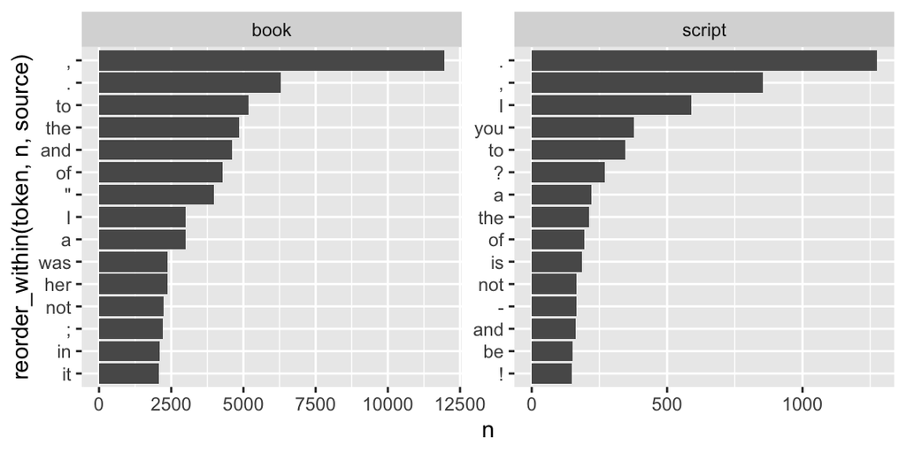

# 3 How to cite

This is a citation (Picoral and Carvalho 2020; Picoral, Staples, and Reppen 2021). Picoral and Carvalho (2020) argue that something.

# References

Picoral, Adriana, and Ana Maria Carvalho. 2020. “The Acquisition of Preposition+ Article Contractions in L3 Portuguese Among Different L1-Speaking Learners: A Variationist Approach.” *Languages* 5 (4): 45.

Picoral, Adriana, Shelley Staples, and Randi Reppen. 2021. “Automated Annotation of Learner English: An Evaluation of Software Tools.” *International Journal of Learner Corpus Research* 7 (1): 17–52.